# Final Production Analysis

#Prelims

```r
library(ggplot2)
library(tidyverse)
library(lme4)
library(stringr)
library(languageR)
library(lmerTest)
library(reshape2)
library(grid)
source("helpers.R")
```

# Data

I also use a custom color palette, so I include the code for that here as well[^1].

```r
bran_palette = c("#7ae7e5", "#fe5f55", "#B2A6DE", "#14342b", "#69385c")
theme_set(theme_minimal())
```

### Frequency Data

We also need the frequency data!

```r
frequency <- read.csv("freq_vals.csv")
```

```r
lib_cols <- c('ABC','CNN','PBS','NBC','MSNBC','NPR','CBS')
```

```r
frequency <- frequency %>%
  mutate(total_left = rowSums(frequency[lib_cols])) %>%
  mutate(total_right = FOX) %>%
  mutate(all_wpm = ((total_left + total_right) / 121500000) * 1000000) %>%
  mutate(left_wpm = (total_left/109300000) * 1000000) %>%
  mutate(right_wpm = (total_right/12200000) * 1000000) %>%
  mutate(neutral_binary = ifelse(gender=="neutral",1,0)) %>%
  mutate(morph_type = ifelse(lexeme!= 'actor' & lexeme!= 'host' & lexeme !='hunter' & lexeme!= 'villain' & lexeme!= 'heir' & lexeme!= 'hero','compound','adoption')) %>%
  rename(form = word)
```

```r
non_inds <- c('ABC','CNN','PBS','NBC','MSNBC','NPR','CBS','FOX')
```

```r
test_freq <- read.csv("freq_vals.csv")
test_freq <- test_freq %>%
  mutate(total = rowSums(test_freq[non_inds]))
test_freq[test_freq == 0.00000000] <- 0.0001
test_freq <- test_freq %>%
  mutate(total_wpm = (total/121500000) * 1000000) %>%
  mutate(log_total = log(total_wpm))
```

```r
frequency %>%
  group_by(lexeme)
```

| form | lexeme | gender | ABC | NBC | CBS | CNN | FOX | MSNBC | PBS | NPR | IND | total_left | total_right | all_wpm | left_wpm | right_wpm | neutral_binary | morph_type |
| --- | --- | --- | --- | --- | --- | --- | --- | --- | --- | --- | --- | --- | --- | --- | --- | --- | --- | --- |
| congressperson | congressperson | neutral | 15 | 0 | 3 | 11 | 2 | 0 | 0 | 4 | 8 | 33 | 2 | 2.880658e-01 | 0.301921317 | 0.16393443 | 1 | compound |
| congressman | congressperson | male | 1996 | 536 | 1228 | 3821 | 2942 | 84 | 1672 | 1076 | 230 | 10413 | 2942 | 1.099177e+02 | 95.269899360 | 241.14754098 | 0 | compound |
| congresswoman | congressperson | female | 280 | 77 | 261 | 487 | 485 | 7 | 287 | 166 | 6 | 1565 | 485 | 1.687243e+01 | 14.318389753 | 39.75409836 | 0 | compound |
| actress | actor | female | 948 | 495 | 582 | 976 | 164 | 36 | 137 | 691 | 140 | 3865 | 164 | 3.316049e+01 | 35.361390668 | 13.44262295 | 0 | adoption |
| actor | actor | male_neutral | 1931 | 913 | 957 | 1664 | 321 | 59 | 342 | 2165 | 128 | 8031 | 321 | 6.874074e+01 | 73.476669716 | 26.31147541 | 0 | adoption |
| anchorman | anchor | male | 27 | 19 | 36 | 39 | 11 | 2 | 6 | 21 | 5 | 150 | 11 | 1.325103e+00 | 1.372369625 | 0.90163934 | 0 | compound |
| anchorwoman | anchor | female | 10 | 1 | 8 | 2 | 0 | 0 | 3 | 3 | 1 | 27 | 0 | 2.222222e-01 | 0.247026532 | 0.00000000 | 0 | compound |
| businessperson | businessperson | neutral | 5 | 2 | 11 | 7 | 4 | 0 | 10 | 9 | 2 | 44 | 4 | 3.950617e-01 | 0.402561757 | 0.32786885 | 1 | compound |
| businesswoman | businessperson | female | 124 | 20 | 29 | 23 | 8 | 0 | 15 | 12 | 3 | 223 | 8 | 1.901235e+00 | 2.040256176 | 0.65573770 | 0 | compound |
| businessman | businessperson | male | 335 | 108 | 274 | 245 | 216 | 9 | 177 | 213 | 30 | 1361 | 216 | 1.297942e+01 | 12.451967063 | 17.70491803 | 0 | compound |

[output cut: 44 more lines]

Re-write frequency to avoid zero numbers!

```r
frequency[frequency == 0.00000000] <- 0.0001
```

Take log frequency of each media type.

```r
frequency <- frequency %>%
  mutate(log_right = log(right_wpm), log_left = log(left_wpm), log_all = log(all_wpm))
```

Create media difference

```r
frequency <- frequency %>%
  mutate(media_diff = log_left - log_right) %>%
  mutate(nonexistent = ifelse(media_diff == 0 & log_left < -4,"true","false")) %>%
  mutate(freq_gender = ifelse(form == "actress" | form == "anchorwoman" | form == "stewardess" | form == "businesswoman" | form == 'camerawoman' | form == 'congresswoman' | form == 'craftswoman' | form == 'crewwoman' | form == 'firewoman' | form == 'forewoman'  | form == 'heiress' | form == 'heroine' | form == 'hostess' | form == 'huntress' | form == 'laywoman' | form == 'policewoman' | form == 'saleswoman' | form == 'stuntwoman' | form == 'villainess' | form == 'weatherwoman',"female",ifelse(form == "anchor" | form == "flight attendant" | form == "businessperson" | form == 'camera operator' | form == 'congressperson' | form == 'craftsperson' | form == 'crewmember' | form == 'firefighter' | form == 'foreperson' | form == 'layperson' | form == 'police officer' | form == 'salesperson' | form == 'stunt double' | form == 'meteorologist',"neutral",ifelse(form == "anchorman" | form == "steward" | form == "businessman" | form == 'cameraman' | form == 'congressman' | form == 'craftsman' | form == 'crewman' | form == 'fireman' | form == 'foreman' | form == 'layman' | form == 'policeman' | form == 'salesman' | form == 'stuntman' | form == 'weatherman',"male",'neutral'))))
```

```r
frequency <- subset(frequency, select = -c(ABC,CNN,PBS,NBC,MSNBC,NPR,CBS,FOX))
```

```r
freq_log_all <- frequency %>%
  select(lexeme,freq_gender,log_all) %>%
  pivot_wider(names_from = freq_gender,values_from = log_all,names_prefix="log_all_")
```

```r
freq_log_right <- frequency %>%
  select(lexeme,freq_gender,log_right) %>%
  pivot_wider(names_from = freq_gender,values_from = log_right,names_prefix="log_right_")
```

```r
freq_log_left <- frequency %>%
  select(lexeme,freq_gender,log_left) %>%
  pivot_wider(names_from = freq_gender,values_from = log_left,names_prefix="log_left_")
```

```r
freq_lex <- left_join(freq_log_all,freq_log_right,by="lexeme")
```

```r
freq_lex <- left_join(freq_lex,freq_log_left,by="lexeme")
```

```r
freq_all <- frequency %>%
  select(lexeme,freq_gender,all_wpm) %>%
  pivot_wider(names_from = freq_gender,values_from = all_wpm,names_prefix="all_wpm_")
```

```r
freq_right <- frequency %>%
  select(lexeme,freq_gender,right_wpm) %>%
  pivot_wider(names_from = freq_gender,values_from = right_wpm,names_prefix="right_wpm_")
```

```r
freq_left <- frequency %>%
  select(lexeme,freq_gender,left_wpm) %>%
  pivot_wider(names_from = freq_gender,values_from = left_wpm,names_prefix="left_wpm_")
```

```r
net_lex <- left_join(freq_all,freq_right,by="lexeme")
```

```r
net_lex <- left_join(net_lex,freq_left,by="lexeme")
```

```r
net_lex <- net_lex %>%
  mutate(morph_type = ifelse(lexeme!= 'actor' & lexeme!= 'host' & lexeme !='hunter' & lexeme!= 'villain' & lexeme!= 'heir' & lexeme!= 'hero','compound','adoption')) %>%
  mutate(
    fem_odds = all_wpm_neutral / all_wpm_female,
    male_odds = case_when(
      morph_type == "adoption" ~ log(all_wpm_neutral / all_wpm_neutral),
      morph_type == "compound" ~ log(all_wpm_neutral / all_wpm_male)
    )
  )
```

### Heavy Data Analysis; DANGER ZONE

```r
freq_lex <- freq_lex %>%
  mutate(morph_type = ifelse(lexeme!= 'actor' & lexeme!= 'host' & lexeme !='hunter' & lexeme!= 'villain' & lexeme!= 'heir' & lexeme!= 'hero','compound','adoption')) %>%
  mutate(
    rel_fem_odds = log_all_neutral / log_all_female,
    rel_male_odds = case_when(
      morph_type == "adoption" ~ log_all_neutral / log_all_neutral,
      morph_type == "compound" ~ log_all_neutral / log_all_male
    )
  )
```

### Norming Data

And here is the norming data values:

```r
norming_data <- read.csv("norming_data.csv") %>%
  filter(id!="example1") %>% # Will filter out non-critical trials, i.e. the example trial from the beginning of the experiment
  mutate(equalized_response = ifelse(scale=="FM",8-response,response)) %>% # This will render all data points on the same scale, as participants randomly received either "very likely a man" or "very likely a woman" as the left end of their response scale, with the other appearing at the right end
  mutate(orthog = ifelse(orthog=="sroceress","sorceress",orthog)) %>% # Fixes a typo
  mutate(id = ifelse(id=="Stunt_double","stunt double",id)) %>% # This, as well as all lines below it, convert compounds formed by spaces from their underscore forms to their spaced forms (e.g. police_officer -> Police officer)
  mutate(id = ifelse(id=="Police_officer","police officer",id)) %>%
  mutate(id = ifelse(id=="Flight_attendant","flight attendant",id)) %>%
  mutate(id = ifelse(id=="Anchor","anchor",id)) %>%
  mutate(id = ifelse(id=="Businessperson","businessperson",id)) %>%
   mutate(id = ifelse(id=="Camera","camera operator",id)) %>%
  mutate(id = ifelse(id=="Congressperson","congressperson",id)) %>%
  mutate(id = ifelse(id=="Craftsperson","craftsperson",id)) %>%
  mutate(id = ifelse(id=="Crewmember","crewmember",id)) %>%
  mutate(id = ifelse(id=="Firefighter","firefighter",id)) %>%
  mutate(id = ifelse(id=="Foreperson","foreperson",id)) %>%
  mutate(id = ifelse(id=="Layperson","layperson",id)) %>%
  mutate(id = ifelse(id=="Meteorologist","meteorologist",id)) %>%
  mutate(id = ifelse(id=="Salesperson","salesperson",id)) %>%
  mutate(id = ifelse(id=="Actor","actor",id)) %>%
  mutate(id = ifelse(id=="Heir","heir",id)) %>%
  mutate(id = ifelse(id=="Hero","hero",id)) %>%
  mutate(id = ifelse(id=="Host","host",id)) %>%
  mutate(id = ifelse(id=="Hunter","hunter",id)) %>%
  mutate(id = ifelse(id=="Villain","villain",id)) %>%
  mutate(orthog = ifelse(orthog=="airline steward","steward",orthog)) %>%
  mutate(orthog = ifelse(orthog=="airline stewardess","stewardess",orthog))
```

```r
norming_exclusion <- norming_data %>%
  filter(gender=="female") %>%
  group_by(workerid) %>%
  summarize(female_mean = mean(equalized_response)) %>%
  unique() %>%
  mutate(exclusion = female_mean < mean(female_mean) - 2*sd(female_mean)) %>%
  filter(exclusion==TRUE)
```

```r
norming_data <- norming_data[!(norming_data$workerid %in% norming_exclusion$workerid),]
```

```r
norming_means <- norming_data %>%
  filter(neutral_morh !="male_adoption") %>%
  group_by(orthog,id) %>%
  summarise(indi_mean = mean(equalized_response), trial_count=n()) %>%
  rename(form = orthog) %>%
  rename(lexeme =id)
```

```r
norming_adoptions <- norming_data %>%
  filter(neutral_morh == "male_adoption") %>%
  group_by(orthog) %>%
  summarise(indi_mean = mean(equalized_response), trial_count=n()) %>%
  mutate(lexeme = ifelse(orthog=="actress","actor",ifelse(orthog=="heiress","heir",ifelse(orthog=="heroine","hero",ifelse(orthog=="hostess","host",ifelse(orthog=="huntress","hunter",ifelse(orthog=="villainess","villain",orthog))))))) %>%
    rename(form = orthog)
```

```r
norming_adoptions <- norming_adoptions[, c("lexeme", "form", "indi_mean", "trial_count")]
```

```r
norming_means <- rbind(norming_means,norming_adoptions) %>%
  rename(lexeme_norm = lexeme)
```

**Neutrals Only**

```r
norming_means_neutral <- norming_data %>%
  filter(gender=="neutral") %>%
  filter(neutral_morh !="male_adoption") %>%
  group_by(orthog,id) %>%
  summarise(indi_mean = mean(equalized_response), trial_count=n()) %>%
  rename(form = orthog) %>%
  rename(lexeme =id)
```

```r
norming_adoptions_neutral <- norming_data %>%
  filter(gender=="neutral") %>%
  filter(neutral_morh == "male_adoption") %>%
  group_by(orthog) %>%
  summarise(indi_mean = mean(equalized_response), trial_count=n()) %>%
  mutate(lexeme = ifelse(orthog=="actress","actor",ifelse(orthog=="heiress","heir",ifelse(orthog=="heroine","hero",ifelse(orthog=="hostess","host",ifelse(orthog=="huntress","hunter",ifelse(orthog=="villainess","villain",orthog))))))) %>%
    rename(form = orthog)
```

```r
norming_adoptions_neutral <- norming_adoptions_neutral[, c("lexeme", "form", "indi_mean", "trial_count")]
```

```r
norming_means_neutral <- rbind(norming_means_neutral,norming_adoptions_neutral)
```

# Analysis

## Data Read-in

```r
prod_data <- read.csv("production_data.csv")
```

## Exclusions

```r
prod_exclusion <- prod_data %>% filter(name=='attention') %>%
  group_by(workerid) %>%
  summarise(accuracy = mean(correct)) %>%
  mutate(exclude = ifelse(accuracy < 0.80,'Yes','No')) %>%
  filter(exclude == "Yes")
```

```r
prod_data <- prod_data[!(prod_data$workerid %in% prod_exclusion$workerid),]
```

## Additional Information

```r
gender_transcendence_cols <- c('subject_information.gender_q1','subject_information.gender_q2','subject_information.gender_q3','subject_information.gender_q4','subject_information.gender_q5')
gender_linked_cols <- c('subject_information.gender_q6','subject_information.gender_q7','subject_information.gender_q8','subject_information.gender_q9','subject_information.gender_q10','subject_information.gender_q11','subject_information.gender_q12','subject_information.gender_q13')
```

```r
prod_data <- prod_data %>%
  mutate(gender_trans = 100 - (rowMeans(prod_data[gender_transcendence_cols]))) %>%
  mutate(gender_link = rowMeans(prod_data[gender_linked_cols]))
gender_all = c('gender_trans','gender_link')
prod_data <- prod_data %>%
  mutate(gender_total = rowMeans(prod_data[gender_all]))
```

```r
prod_data <- prod_data %>%
  filter(type == "critical") %>%
  mutate(response_gender = ifelse(response == "actress" | response == "anchorwoman" | response == "stewardess" | response == "businesswoman" | response == 'camerawoman' | response == 'congresswoman' | response == 'craftswoman' | response == 'crewwoman' | response == 'firewoman' | response == 'forewoman'  | response == 'heiress' | response == 'heroine' | response == 'hostess' | response == 'huntress' | response == 'laywoman' | response == 'policewoman' | response == 'saleswoman' | response == 'stuntwoman' | response == 'villainess' | response == 'weatherwoman',"female",ifelse(response == "anchor" | response == "flight attendant" | response == "businessperson" | response == 'camera operator' | response == 'congressperson' | response == 'craftsperson' | response == 'crewmember' | response == 'firefighter' | response == 'foreperson' | response == 'layperson' | response == 'police officer' | response == 'salesperson' | response == 'stunt double' | response == 'meteorologist',"neutral",ifelse(response == "anchorman" | response == "steward" | response == "businessman" | response == 'cameraman' | response == 'congressman' | response == 'craftsman' | response == 'crewman' | response == 'fireman' | response == 'foreman' | response == 'layman' | response == 'policeman' | response == 'salesman' | response == 'stuntman' | response == 'weatherman',"male",'neutral')))) %>%
  mutate(congruency = ifelse(gender == response_gender,"true","false")) %>%
  mutate(incongruent = ifelse(gender == "male" & response_gender == "female","incongruent_mtf",ifelse(gender == "female" & response_gender == "male","incongruent_ftm","real"))) %>%
  mutate(neutrality = ifelse(response_gender == "neutral","true","false"))%>%
  mutate(morph_type = ifelse(lexeme!= 'actor' & lexeme!= 'host' & lexeme !='hunter' & lexeme!= 'villain' & lexeme!= 'heir' & lexeme!= 'hero','compound','adoption')) %>%
  mutate(poli_party = ifelse(subject_information.party_alignment == 1 | subject_information.party_alignment == 2,'Republican',ifelse(subject_information.party_alignment == 4 | subject_information.party_alignment == 5,'Democrat','Non-Partisan'))) %>%
  mutate(response_neutral = ifelse(response_gender == "neutral",1,0)) %>%
  mutate(young_old = ifelse(subject_information.age > 40,"old","young")) %>%
  rename(form = response) %>%
  filter(!is.na(subject_information.age)) %>%
  filter(!is.na(poli_party))
```

**Joining independent data** Now that we have this information, we want to left join our frequency information so that we can use it in later analyses. We begin by adding the norming values’ means, of all forms.

```r
final_prod <- left_join(prod_data,norming_means,by="form")
```

```r
final_prod <- left_join(final_prod,freq_lex,by="lexeme")
```

Now we can add additional lexeme-level norming information for the neutral forms, so that we can tackle the question of what role real-world expectations have on processing times.

```r
final_prod <- left_join(final_prod,norming_means_neutral,by="lexeme")
```

```r
final_prod <- subset(final_prod, select = -c(form.y,trial_count.y,trial_count.x,error,subject_information.comments,subject_information.asses,subject_information.enjoyment,subject_information.gender_q1,subject_information.gender_q2,subject_information.gender_q3,subject_information.gender_q4,subject_information.gender_q5,subject_information.gender_q6,subject_information.gender_q7,subject_information.gender_q8,subject_information.gender_q9,subject_information.gender_q10,subject_information.gender_q11,subject_information.gender_q12,subject_information.gender_q13,lexeme_norm)) %>%
  rename(form_norm = indi_mean.x, lexeme_norm = indi_mean.y, form = form.x)
```

```r
net_lex <- net_lex %>%
  select(lexeme,fem_odds,male_odds)
```

```r
final_prod <- left_join(final_prod,net_lex,by="lexeme")
```

### Heavy data manipulation; DANGER ZONE

```r
final_prod <- final_prod %>%
  mutate(log_odds = case_when(
    gender == "male" ~ male_odds,
    gender == "female" ~ fem_odds
  )) %>%
  mutate(c_gender_total = scale(gender_total,scale=FALSE)) %>%
  mutate(c_gender_trans = scale(gender_trans,scale=FALSE)) %>%
  mutate(c_gender_link = scale(gender_link,scale=FALSE))
```

### Before we subset out the incongruents

```r
prod_all <- final_prod %>%
  mutate(poli_party = factor(poli_party,ordered = FALSE)) %>%
  mutate(trial_gender = factor(gender,ordered = FALSE)) %>%
  mutate(c_trial_gender = scale(as.numeric(trial_gender),scale=FALSE))
```

```r
final_prod <- final_prod %>%
  mutate(poli_party = factor(poli_party,ordered = FALSE)) %>%
  mutate(trial_gender = factor(gender,ordered = FALSE)) %>%
  mutate(c_trial_gender = scale(as.numeric(trial_gender),scale=FALSE)) %>%
  filter(incongruent == "real")
```

```r
final_prod$poli_party = relevel(final_prod$poli_party, ref="Democrat")
final_prod$trial_gender = relevel(final_prod$trial_gender, ref="male")
```

```r
final_prod <- final_prod %>%
  mutate(c_age = scale(subject_information.age, scale=FALSE)) %>%
  mutate(c_log_odds = scale(log_odds, scale=TRUE))
```

```r
final_prod$poli_party = relevel(final_prod$poli_party, ref="Democrat")
final_prod$trial_gender = relevel(final_prod$trial_gender, ref="male")
```

```r
test_ex <- final_prod %>%
  filter(lexeme != "firefighter") %>%
  filter(lexeme != "meteorologist")
```

```r
lom <- glmer(as.factor(response_neutral)~c_trial_gender*c_gender_total + c_log_odds + (1|workerid) + (1|lexeme),data=test_ex,family = "binomial",control = glmerControl(optCtrl = list(maxfun=2e4)))
```

```r
tt <- getME(lom,"theta")
ll <- getME(lom,"lower")
min(tt[ll==0])
```

```
[1] 0.8812823
```

```r
summary(lom)
```

```
Generalized linear mixed model fit by maximum likelihood (Laplace Approximation) ['glmerMod']
 Family: binomial  ( logit )
Formula: as.factor(response_neutral) ~ c_trial_gender * c_gender_total +      c_log_odds + (1 | workerid) + (1 | lexeme)
   Data: test_ex
Control: glmerControl(optCtrl = list(maxfun = 20000))

     AIC      BIC   logLik deviance df.resid
  5142.3   5187.4  -2564.2   5128.3     4640

Scaled residuals:
    Min      1Q  Median      3Q     Max
-5.1762 -0.6554 -0.1600  0.6440  4.5083

Random effects:
 Groups   Name        Variance Std.Dev.
 workerid (Intercept) 0.7767   0.8813
 lexeme   (Intercept) 1.3418   1.1584
Number of obs: 4647, groups:  workerid, 271; lexeme, 18

Fixed effects:
                               Estimate Std. Error z value Pr(>|z|)
(Intercept)                    2.745569   0.447976   6.129 8.85e-10 ***
c_trial_gender                 1.031863   0.078270  13.183  < 2e-16 ***
c_gender_total                -0.023958   0.004103  -5.839 5.27e-09 ***
c_log_odds                    12.354897   1.525254   8.100 5.49e-16 ***
c_trial_gender:c_gender_total -0.002164   0.004564  -0.474    0.635
---
Signif. codes:  0 ‘***’ 0.001 ‘**’ 0.01 ‘*’ 0.05 ‘.’ 0.1 ‘ ’ 1

Correlation of Fixed Effects:
            (Intr) c_trl_ c_gnd_ c_lg_d
c_tril_gndr  0.263
c_gendr_ttl -0.018 -0.040
c_log_odds   0.780  0.343 -0.023
c_trl_gn:__  0.022 -0.004 -0.014  0.031
```

```r
summary(final_prod$c_log_odds)
```

```
       V1
 Min.   :-0.2372
 1st Qu.:-0.2366
 Median :-0.2365
 Mean   : 0.0000
 3rd Qu.:-0.2326
 Max.   : 4.9006
```

```r
table(final_prod$c_log_odds,final_prod$lexeme)
```

```
                      actor anchor businessperson camera operator congressperson craftsperson crewmember firefighter flight attendant
  -0.237234781450561      0      0              0               0            152            0          0           0                0
  -0.237031824032831      0      0              0               0              0          123          0           0                0
  -0.236989885400256      0      0            142               0              0            0          0           0                0
  -0.236973919240835      0      0              0             143              0            0          0           0                0
  -0.236941475106197      0      0              0               0              0            0          0           0                0
  -0.236824963077837      0      0              0               0              0            0          0           0                0
  -0.236754131486282      0      0              0               0              0            0          0           0                0
  -0.236701674663066      0      0              0               0              0            0          0           0                0
  -0.23666793238433       0      0              0               0              0            0        130           0                0
  -0.236641141637793    140      0              0               0              0            0          0           0                0
  -0.236639436589734      0      0              0               0            112            0          0           0                0
  -0.236620390032473      0      0            124               0              0            0          0           0                0
  -0.236552428006589      0      0              0               0              0            0          0           0              136
  -0.236543455021925      0      0              0               0              0            0          0         140                0
  -0.236525910367868      0      0              0               0              0            0          0           0                0
  -0.236517969805892      0      0              0               0              0            0          0           0                0
  -0.236491966550116      0      0              0               0              0            0          0           0                0
  -0.236434120038333    130      0              0               0              0            0          0           0                0
  -0.236359273746376      0      0              0               0              0            0          0           0                0
  -0.236275224654902      0    123              0               0              0            0          0           0                0
  -0.236191739685086      0      0              0             115              0            0          0           0                0
  -0.236069901822352      0      0              0               0              0            0          0           0                0
  -0.236041939034184      0      0              0               0              0            0          0           0              129
  -0.234292581620277      0      0              0               0              0            0          0           0                0
  -0.232646457613733      0      0              0               0              0            0          0           0                0
  -0.232335020211116      0      0              0               0              0            0          0           0                0
  -0.23018723026142       0      0              0               0              0            0          0           0                0
  -0.228421627184994      0      0              0               0              0          107          0           0                0
  -0.228146889914409      0      0              0               0              0            0          0           0                0
  -0.213405396231176      0    139              0               0              0            0          0           0                0
  -0.210808851615537      0      0              0               0              0            0          0           0                0
  -0.0229337658650215     0      0              0               0              0            0        132           0                0
  3.71694531015848        0      0              0               0              0            0          0           0                0
  4.90055539136152        0      0              0               0              0            0          0         127                0

                      foreperson heir hero host hunter layperson meteorologist police officer salesperson stunt double villain
  -0.237234781450561           0    0    0    0      0         0             0              0           0            0       0
  -0.237031824032831           0    0    0    0      0         0             0              0           0            0       0
  -0.236989885400256           0    0    0    0      0         0             0              0           0            0       0
```

[output cut: 16 more lines]

```
  -0.236275224654902           0    0    0    0      0         0             0              0           0            0       0
  -0.236191739685086           0    0    0    0      0         0             0              0           0          129       0
  -0.236069901822352           0    0    0    0      0         0             0              0         123            0       0
  -0.236041939034184           0    0    0    0      0         0             0              0           0            0       0
  -0.234292581620277           0    0  126    0      0         0             0              0           0            0       0
  -0.232646457613733           0    0    0    0      0       103             0              0           0            0       0
  -0.232335020211116           0    0    0  132      0         0             0              0           0            0       0
  -0.23018723026142            0    0    0    0      0         0             0              0           0            0     142
  -0.228421627184994           0    0    0    0      0         0             0              0           0            0       0
  -0.228146889914409           0    0    0    0      0         0             0            140           0            0       0
  -0.213405396231176           0    0    0    0      0         0             0              0           0            0       0
  -0.210808851615537           0    0    0    0    139         0             0              0           0            0       0
  -0.0229337658650215          0    0    0    0      0         0             0              0           0            0       0
  3.71694531015848             0    0    0    0      0         0           135              0           0            0       0
  4.90055539136152             0    0    0    0      0         0             0              0           0            0       0
```

```r
summary(lom)
```

```
Generalized linear mixed model fit by maximum likelihood (Laplace Approximation) ['glmerMod']
 Family: binomial  ( logit )
Formula: as.factor(response_neutral) ~ c_trial_gender * c_gender_total +      c_log_odds + (1 | workerid) + (1 | lexeme)
   Data: test_ex
Control: glmerControl(optCtrl = list(maxfun = 20000))

     AIC      BIC   logLik deviance df.resid
  5142.3   5187.4  -2564.2   5128.3     4640

Scaled residuals:
    Min      1Q  Median      3Q     Max
-5.1762 -0.6554 -0.1600  0.6440  4.5083

Random effects:
 Groups   Name        Variance Std.Dev.
 workerid (Intercept) 0.7767   0.8813
 lexeme   (Intercept) 1.3418   1.1584
Number of obs: 4647, groups:  workerid, 271; lexeme, 18

Fixed effects:
                               Estimate Std. Error z value Pr(>|z|)
(Intercept)                    2.745569   0.447976   6.129 8.85e-10 ***
c_trial_gender                 1.031863   0.078270  13.183  < 2e-16 ***
c_gender_total                -0.023958   0.004103  -5.839 5.27e-09 ***
c_log_odds                    12.354897   1.525254   8.100 5.49e-16 ***
c_trial_gender:c_gender_total -0.002164   0.004564  -0.474    0.635
---
Signif. codes:  0 ‘***’ 0.001 ‘**’ 0.01 ‘*’ 0.05 ‘.’ 0.1 ‘ ’ 1

Correlation of Fixed Effects:
            (Intr) c_trl_ c_gnd_ c_lg_d
c_tril_gndr  0.263
c_gendr_ttl -0.018 -0.040
c_log_odds   0.780  0.343 -0.023
c_trl_gn:__  0.022 -0.004 -0.014  0.031
```

```r
dems <- test_ex %>%
  filter(poli_party == "Democrat")
```

```r
dem_model <- glmer(as.factor(response_neutral)~c_trial_gender*c_gender_total + c_log_odds + (1|workerid) + (1|lexeme),data=dems,family="binomial")
```

```r
summary(dem_model)
```

```
Generalized linear mixed model fit by maximum likelihood (Laplace Approximation) ['glmerMod']
 Family: binomial  ( logit )
Formula: as.factor(response_neutral) ~ c_trial_gender * c_gender_total +      c_log_odds + (1 | workerid) + (1 | lexeme)
   Data: dems

     AIC      BIC   logLik deviance df.resid
  2487.2   2527.0  -1236.6   2473.2     2182

Scaled residuals:
    Min      1Q  Median      3Q     Max
-5.2871 -0.6928  0.2967  0.6385  3.1961

Random effects:
 Groups   Name        Variance Std.Dev.
 workerid (Intercept) 0.8569   0.9257
 lexeme   (Intercept) 1.0524   1.0259
Number of obs: 2189, groups:  workerid, 128; lexeme, 18

Fixed effects:
                               Estimate Std. Error z value Pr(>|z|)
(Intercept)                    2.211833   0.573330   3.858 0.000114 ***
c_trial_gender                 0.861737   0.124069   6.946 3.77e-12 ***
c_gender_total                -0.033759   0.007274  -4.641 3.47e-06 ***
c_log_odds                     9.234366   2.222727   4.155 3.26e-05 ***
c_trial_gender:c_gender_total -0.004348   0.007914  -0.549 0.582694
---
Signif. codes:  0 ‘***’ 0.001 ‘**’ 0.01 ‘*’ 0.05 ‘.’ 0.1 ‘ ’ 1

Correlation of Fixed Effects:
            (Intr) c_trl_ c_gnd_ c_lg_d
c_tril_gndr  0.273
c_gendr_ttl  0.066 -0.048
c_log_odds   0.887  0.313 -0.019
c_trl_gn:__  0.027  0.429 -0.014  0.036
```

```r
reps <- test_ex %>%
  filter(poli_party == "Republican")
```

```r
rep_model <- glmer(as.factor(response_neutral)~c_trial_gender*c_gender_total + c_log_odds + (1|workerid) + (1|lexeme),data=reps,family = "binomial")
```

```r
summary(rep_model)
```

```
Generalized linear mixed model fit by maximum likelihood (Laplace Approximation) ['glmerMod']
 Family: binomial  ( logit )
Formula: as.factor(response_neutral) ~ c_trial_gender * c_gender_total +      c_log_odds + (1 | workerid) + (1 | lexeme)
   Data: reps

     AIC      BIC   logLik deviance df.resid
  1997.3   2036.0   -991.7   1983.3     1842

Scaled residuals:
    Min      1Q  Median      3Q     Max
-2.4710 -0.6567 -0.2839  0.6228  4.7358

Random effects:
 Groups   Name        Variance Std.Dev.
 workerid (Intercept) 0.3318   0.5761
 lexeme   (Intercept) 1.7600   1.3267
Number of obs: 1849, groups:  workerid, 108; lexeme, 18

Fixed effects:
                                Estimate Std. Error z value Pr(>|z|)
(Intercept)                    2.7097830  0.6209990   4.364 1.28e-05 ***
c_trial_gender                 1.2722553  0.1425944   8.922  < 2e-16 ***
c_gender_total                 0.0007437  0.0051754   0.144    0.886
c_log_odds                    14.5955470  2.3182458   6.296 3.06e-10 ***
c_trial_gender:c_gender_total -0.0082418  0.0074627  -1.104    0.269
---
Signif. codes:  0 ‘***’ 0.001 ‘**’ 0.01 ‘*’ 0.05 ‘.’ 0.1 ‘ ’ 1

Correlation of Fixed Effects:
            (Intr) c_trl_ c_gnd_ c_lg_d
c_tril_gndr  0.251
c_gendr_ttl -0.079  0.025
c_log_odds   0.850  0.312 -0.007
c_trl_gn:__  0.004 -0.455 -0.041  0.001
```

```r
inds <- test_ex %>%
  filter(poli_party == "Non-Partisan")
```

```r
ind_model <- glmer(response_neutral~c_trial_gender*c_gender_total + c_log_odds + (1|workerid) + (1|lexeme),data=inds, family="binomial")
```

```r
summary(ind_model)
```

```
Generalized linear mixed model fit by maximum likelihood (Laplace Approximation) ['glmerMod']
 Family: binomial  ( logit )
Formula: response_neutral ~ c_trial_gender * c_gender_total + c_log_odds +      (1 | workerid) + (1 | lexeme)
   Data: inds

     AIC      BIC   logLik deviance df.resid
   697.5    728.4   -341.8    683.5      602

Scaled residuals:
    Min      1Q  Median      3Q     Max
-3.5599 -0.6375 -0.1514  0.6120  2.5552

Random effects:
 Groups   Name        Variance Std.Dev.
 workerid (Intercept) 0.8195   0.9053
 lexeme   (Intercept) 1.7930   1.3390
Number of obs: 609, groups:  workerid, 35; lexeme, 18

Fixed effects:
                                Estimate Std. Error z value Pr(>|z|)
(Intercept)                    3.4403941  1.1292040   3.047 0.002313 **
c_trial_gender                 1.0414385  0.2230942   4.668 3.04e-06 ***
c_gender_total                -0.0054951  0.0150185  -0.366 0.714449
c_log_odds                    15.2424915  4.6237400   3.297 0.000979 ***
c_trial_gender:c_gender_total  0.0005931  0.0165798   0.036 0.971462
---
Signif. codes:  0 ‘***’ 0.001 ‘**’ 0.01 ‘*’ 0.05 ‘.’ 0.1 ‘ ’ 1

Correlation of Fixed Effects:
            (Intr) c_trl_ c_gnd_ c_lg_d
c_tril_gndr  0.299
c_gendr_ttl  0.054  0.014
c_log_odds   0.946  0.320  0.034
c_trl_gn:__ -0.020  0.123  0.009 -0.022
```

```r
all_poli <- glmer(response_neutral~poli_party + (1|lexeme) + (1|workerid), data=test_ex, family="binomial")
```

```r
summary(all_poli)
```

```
Generalized linear mixed model fit by maximum likelihood (Laplace Approximation) ['glmerMod']
 Family: binomial  ( logit )
Formula: response_neutral ~ poli_party + (1 | lexeme) + (1 | workerid)
   Data: test_ex

     AIC      BIC   logLik deviance df.resid
  5330.0   5362.2  -2660.0   5320.0     4642

Scaled residuals:
    Min      1Q  Median      3Q     Max
-4.5910 -0.6780 -0.2091  0.7002  4.7092

Random effects:
 Groups   Name        Variance Std.Dev.
 workerid (Intercept) 0.6611   0.8131
 lexeme   (Intercept) 1.2428   1.1148
Number of obs: 4647, groups:  workerid, 271; lexeme, 18

Fixed effects:
                       Estimate Std. Error z value Pr(>|z|)
(Intercept)              0.3196     0.2772   1.153   0.2490
poli_partyNon-Partisan  -0.3817     0.1889  -2.021   0.0433 *
poli_partyRepublican    -0.8339     0.1304  -6.396 1.59e-10 ***
---
Signif. codes:  0 ‘***’ 0.001 ‘**’ 0.01 ‘*’ 0.05 ‘.’ 0.1 ‘ ’ 1

Correlation of Fixed Effects:
            (Intr) pl_N-P
pl_prtyNn-P -0.149
pl_prtyRpbl -0.216  0.318
```

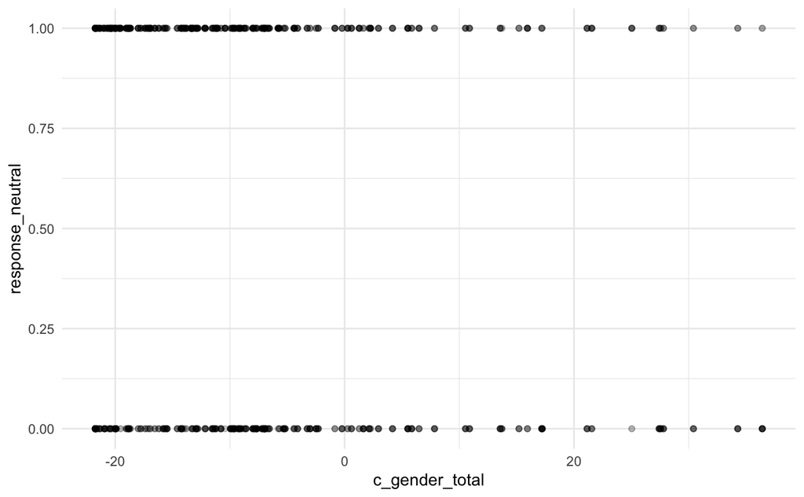

```r
dems %>%
  ggplot(aes(x=c_gender_total,y=response_neutral)) +
  geom_point(alpha=0.1)
```

```r
prop.table(table(final_prod$response_gender, final_prod$poli_party))
```

```
            Democrat Non-Partisan Republican
  female  0.10059857   0.03340413 0.11411469
  male    0.08939950   0.02819077 0.10426723
  neutral 0.28074918   0.06951149 0.17976443
```

```r
final_prod %>%
  group_by(trial_gender) %>%
  summarise(mean_neutral = mean(response_neutral))
```

| trial_gender | mean_neutral |
| --- | --- |
| male | 0.5703067 |
| female | 0.4870259 |

[output not shown]

```r
summary(final_prod)
```

```
    workerid    proliferate.condition    choice             correct     gender             lexeme              name
 Min.   : 907   Length:5179           Length:5179        Min.   :0   Length:5179        Length:5179        Length:5179
 1st Qu.:1712   Class :character      Class :character   1st Qu.:0   Class :character   Class :character   Class :character
 Median :2815   Mode  :character      Mode  :character   Median :0   Mode  :character   Mode  :character   Mode  :character
 Mean   :2565                                            Mean   :0
 3rd Qu.:3691                                            3rd Qu.:0
 Max.   :3762                                            Max.   :0

     form             trial_id            trial_no         type           subject_information.age subject_information.education
 Length:5179        Length:5179        Min.   : 0.00   Length:5179        Min.   :18.00           Min.   :-1.000
 Class :character   Class :character   1st Qu.:19.00   Class :character   1st Qu.:21.00           1st Qu.: 2.000
 Mode  :character   Mode  :character   Median :39.00   Mode  :character   Median :24.00           Median : 3.000
                                       Mean   :39.12                      Mean   :25.46           Mean   : 2.532
                                       3rd Qu.:59.00                      3rd Qu.:29.00           3rd Qu.: 3.000
                                       Max.   :79.00                      Max.   :65.00           Max.   : 4.000

 subject_information.gender subject_information.language subject_information.party_alignment subject_information.price system.Browser
 Length:5179                Length:5179                  Min.   :1.000                       Min.   :0.000             Length:5179
 Class :character           Class :character             1st Qu.:2.000                       1st Qu.:1.000             Class :character
 Mode  :character           Mode  :character             Median :3.000                       Median :1.000             Mode  :character
                                                         Mean   :3.262                       Mean   :0.933
                                                         3rd Qu.:5.000                       3rd Qu.:1.000
                                                         Max.   :5.000                       Max.   :1.000

  system.OS         system.screenH   system.screenW time_in_minutes   speaker_cond        gender_trans    gender_link     gender_total
 Length:5179        Min.   : 667.0   Min.   : 375   Min.   :  5.060   Length:5179        Min.   : 0.00   Min.   : 0.00   Min.   : 0.000
 Class :character   1st Qu.: 800.0   1st Qu.:1366   1st Qu.:  6.829   Class :character   1st Qu.: 1.60   1st Qu.:13.75   1st Qu.: 9.938
 Mode  :character   Median : 900.0   Median :1440   Median :  8.180   Mode  :character   Median : 8.20   Median :25.38   Median :17.637
                    Mean   : 926.1   Mean   :1528   Mean   :  9.694                      Mean   :12.48   Mean   :30.65   Mean   :21.566
                    3rd Qu.:1080.0   3rd Qu.:1792   3rd Qu.:  9.602                      3rd Qu.:20.00   3rd Qu.:46.75   3rd Qu.:31.812
                    Max.   :1440.0   Max.   :2560   Max.   :117.916                      Max.   :67.60   Max.   :91.12   Max.   :70.112

 response_gender     congruency        incongruent         neutrality        morph_type.x              poli_party   response_neutral
 Length:5179        Length:5179        Length:5179        Length:5179        Length:5179        Democrat    :2438   Min.   :0.00
 Class :character   Class :character   Class :character   Class :character   Class :character   Non-Partisan: 679   1st Qu.:0.00
 Mode  :character   Mode  :character   Mode  :character   Mode  :character   Mode  :character   Republican  :2062   Median :1.00
                                                                                                                    Mean   :0.53
                                                                                                                    3rd Qu.:1.00
                                                                                                                    Max.   :1.00

```

[output cut: 16 more lines]

```
  lexeme_norm       fem_odds          male_odds          log_odds         c_gender_total.V1   c_gender_trans.V1   c_gender_link.V1
 Min.   :2.622   Min.   :    0.02   Min.   :-5.9443   Min.   :   -5.94   Min.   :-21.73704   Min.   :-12.51513   Min.   :-30.95895
 1st Qu.:3.156   1st Qu.:    4.50   1st Qu.:-1.8407   1st Qu.:    0.00   1st Qu.:-11.79954   1st Qu.:-10.91513   1st Qu.:-17.20895
 Median :3.607   Median :   40.00   Median : 0.0000   Median :    1.15   Median : -4.09954   Median : -4.31513   Median : -5.58395
 Mean   :3.554   Mean   : 4829.07   Mean   :-0.7128   Mean   : 2369.56   Mean   : -0.17063   Mean   : -0.03202   Mean   : -0.30923
 3rd Qu.:3.781   3rd Qu.:  232.67   3rd Qu.: 0.8883   3rd Qu.:   40.00   3rd Qu.: 10.07546   3rd Qu.:  7.48487   3rd Qu.: 15.79105
 Max.   :5.097   Max.   :51440.33   Max.   : 3.6640   Max.   :51440.33   Max.   : 48.37546   Max.   : 55.08487   Max.   : 60.16605

 trial_gender   c_trial_gender.V1        c_age.V1         c_log_odds.V1
 male  :2674   Min.   :-0.5000000   Min.   :-7.46129   Min.   :-0.237235
 female:2505   1st Qu.:-0.5000000   1st Qu.:-4.46129   1st Qu.:-0.236641
               Median : 0.5000000   Median :-1.46129   Median :-0.236526
               Mean   : 0.0163159   Mean   : 0.00000   Mean   : 0.000000
               3rd Qu.: 0.5000000   3rd Qu.: 3.53871   3rd Qu.:-0.232646
               Max.   : 0.5000000   Max.   :39.53871   Max.   : 4.900555
```

[^1]: It is my hope and intention that this color palette be color-blind friendly. If you have accessibility concerns, please do not hesitate to reach out to me!